# Homework #1: Simple Linear Regression

Jacob Norman  
2024-09-07

This is the first assignment for the course *ISE537: Statistical Models for Systems Analytics in Industrial Engineering*. I have not used `R` in quite a while, so this will be a great way to get a refresher on basic syntax and get used to new features.

I am choosing to use the new (to me anyway) Quarto document (*.qmd*) instead of an R Markdown (*.rmd*) file. My understanding is that they function very similarly, but the big advantage is that multiple programming languages are supported in a *.qmd* file. For now, we will keep it to just `R`, but good to know I can mix in `Python` or `Julia` if needed.

## 1. True/False

This section covers the true or false questions concerning simple linear regression.

| Q1 | Q2 | Q3 | Q4 | Q5 | Q6 | Q7 | Q8 |
| --- | --- | --- | --- | --- | --- | --- | --- |
| F | T | T | T | T | F | T | F |

## 2. Data Analysis

Before we begin our analysis, it is necessary to import the required packages. Since we will use many of the packages in the `tidyverse` ecosystem, let’s just go ahead and import all of them.

```r
#install.packages("tidyverse")
library("tidyverse")
```

With that, let’s read our data into a tidy dataframe, known as a `tibble`, from the file *machine.csv*. This data set comes from the [UCI Machine Learning Repository](https://archive.ics.uci.edu/dataset/29/computer+hardware).

```r
df <- as_tibble(read.csv("data/machine.csv"))
summary(df)
```

```
    vendor              chmax         performance
 Length:209         Min.   :  0.00   Min.   :   6.0
 Class :character   1st Qu.:  5.00   1st Qu.:  27.0
 Mode  :character   Median :  8.00   Median :  50.0
                    Mean   : 18.27   Mean   : 105.6
                    3rd Qu.: 24.00   3rd Qu.: 113.0
                    Max.   :176.00   Max.   :1150.0
```

We can see that there are three columns in our `df`:

- `vendor` (char): vendor of the CPU
- `chmax` (int): maximum channels in CPU
- `performance` (int): published relative performance of CPU

Let’s get a small preview of what the data looks like:

```r
df %>% head(10)
```

```
# A tibble: 10 × 3
   vendor  chmax performance
   <chr>   <int>       <int>
 1 adviser   128         198
 2 amdahl     32         269
 3 amdahl     32         220
 4 amdahl     32         172
 5 amdahl     16         132
 6 amdahl     32         318
 7 amdahl     32         367
 8 amdahl     32         489
 9 amdahl     32         636
10 amdahl     64        1144
```

### 2.1 Exploratory Data Analysis

Now we are prepared to actually analyze the data. We will start with a simple scatter plot comparing `performance` against `chmax`.

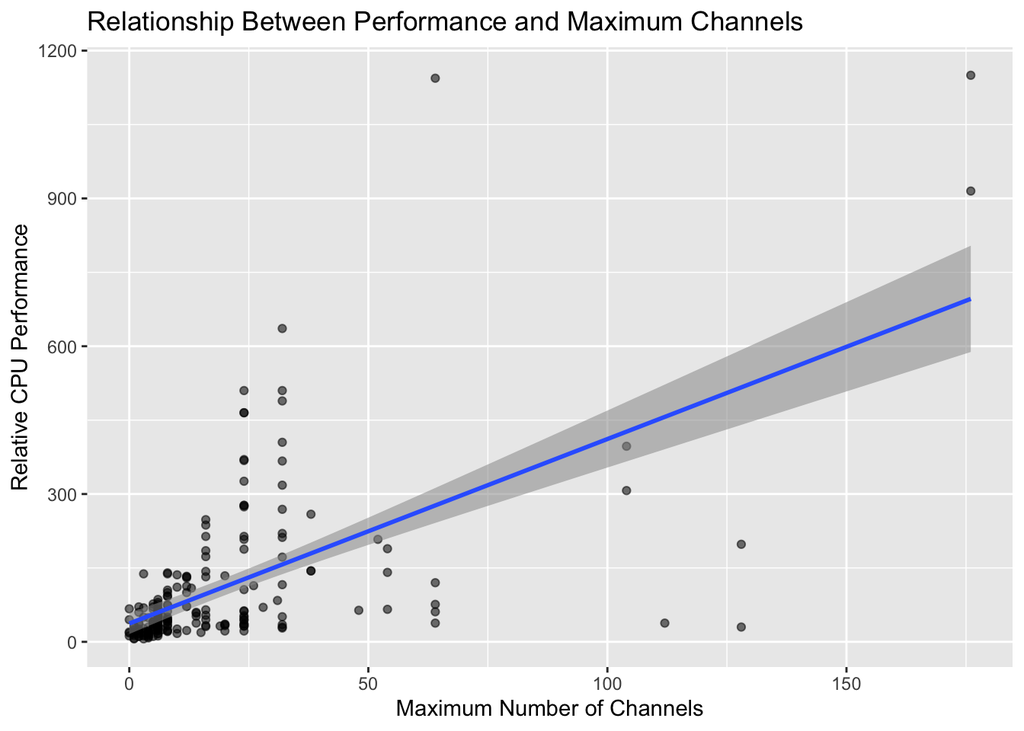

```r
ggplot(df, aes(chmax, performance, alpha=0.5)) +
  geom_point() +
  geom_smooth(formula = y ~ x, method = "lm") +
  labs(title="Relationship Between Performance and Maximum Channels",
       x="Maximum Number of Channels",
       y="Relative CPU Performance") +
  theme(legend.position = "none")
```

Based on the scatter plot and regression line, there appears to be a positive, linear relationship between `chmax` and `performance`. In other words, as the maximum number of channels of a CPU increases, the relative performance of the CPU does as well, generally speaking. It does appear that there is more variation in the relationship as the maximum number of channels exceeds 10.

In order to get a better idea of the strength of the relationship between the two variables, let’s compute the correlation coefficient.

```r
cor(df$chmax, df$performance)
```

```
[1] 0.6052093
```

Pearson’s correlation coefficient is scaled from -1 to +1, so a value of approximately 0.61 indicates that there is a moderate, positive correlation between `chmax` and `performance`.

Based on this exploratory data analysis, it would make sense to model this relationship using simple linear regression. This is because the two variables:

1. Seem to possess an approximately linear relationship upon visual inspection; and
2. Have a moderate, positive correlation between them.

However, keep in mind this does not perfectly capture the relationship between the two variables. Based on the scatter plot and regression line, there are several residuals that are quite large. Additionally, the correlation coefficient is not greater than 0.75, which would indicate a strong relationship. These facts suggest that there are additional sources of variation not being captured in this model.

### 2.2 Fitting the Simple Linear Regression Model

Now we will actually fit a simple linear regression model. The true regression equation with one predictor is:

$$y_i=\beta_0+\beta_1x_i+\epsilon_i$$

However, we do not know the true value of parameters $\beta_0$ and $\beta_1$, so we must estimate them. This gives us the following equation:

$$\hat{y_i}=\hat\beta_0+\hat\beta_1x_i$$

In this case, $\hat{y_i}$ represents estimated `performance` and $x_i$ represents actual `chmax` at a given index $i$.

```r
model1 <- lm(performance ~ chmax, df)
broom::tidy(model1)
```

```
# A tibble: 2 × 5
  term        estimate std.error statistic  p.value
  <chr>          <dbl>     <dbl>     <dbl>    <dbl>
1 (Intercept)    37.2     10.9        3.43 7.33e- 4
2 chmax           3.74     0.342     10.9  2.85e-22
```

The estimated intercept term, $\hat\beta_0$, is 37.23, while the estimated slope term, $\hat\beta_1$, is 3.74. This means that the estimated regression equation, rounded to two decimal places, looks like this:

$$\hat{y_i}=37.23+3.74x_i$$
The estimated slope, $\hat\beta_1$, suggests that for each additional maximum channel in a CPU, the relative performance is estimated to increase by 3.74 units.

Let’s run a 95% confidence interval to determine the range that the true $\beta_1$ might fall in.

```r
confint(model1, level = 0.95)
```

```
                2.5 %    97.5 %
(Intercept) 15.817392 58.633048
chmax        3.069251  4.418926
```

We can say that we are 95% confident that the true value of $\beta_1$ is between 3.07 and 4.42. Since the interval does not contain zero, we can say that this parameter is significant at a 95% level.

Alternatively, we could run a hypothesis test on $\beta_1$ to determine if it is significantly different from zero. Recall the output of `model1`:

```r
broom::tidy(model1)
```

```
# A tibble: 2 × 5
  term        estimate std.error statistic  p.value
  <chr>          <dbl>     <dbl>     <dbl>    <dbl>
1 (Intercept)    37.2     10.9        3.43 7.33e- 4
2 chmax           3.74     0.342     10.9  2.85e-22
```

The second row corresponds to $\hat\beta_1$. We see that the p-value is near zero (2.85e-22), which is less than the significance ($\alpha$) level of 0.01. Therefore, we reject $H_0$ and conclude that there is sufficient evidence to suggest that $\beta_1$ is different from zero. In other words, there is a positive relationship between the maximum number of channels in a CPU and its performance.

## Additional Analysis

Beyond the scope of Homework #1, I am interested to see if the vendor has an impact on the expected performance of a CPU.

First, we will fit a multiple linear regression model which includes `vendor` as a predictor and then write the estimated parameter values for each vendor to a `tibble`.

```r
# model fitting - multiple linear regression
model2 <- lm(performance ~ chmax + vendor, df)

# determine vendor estimates of model2
vendors <- broom::tidy(model2) %>%
  filter(str_detect(term, "vendor"))

# extract name of vendor into new column
vendors$vendor <- str_extract(vendors$term, "vendor(.*)", group = 1)
```

Now, let’s plot our results:

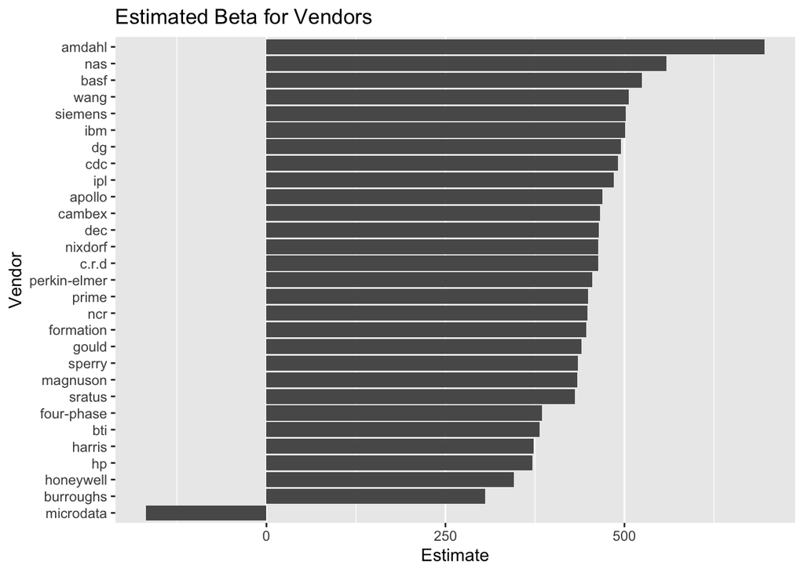

```r
ggplot(vendors, aes(reorder(vendor, estimate), estimate)) +
  geom_bar(stat = "identity") +
  coord_flip() +
  labs(title="Estimated Beta for Vendors",
       x="Vendor",
       y="Estimate") +
  theme(panel.grid.major.y = element_blank())
```

The vendor *Amdahl* seems to have the largest impact on relative CPU performance. Interestingly, *Microdata* is the only vendor with a negative effect on relative performance.

To close, we will verify that all of the `vendor` parameters are significant at significance level $\alpha$=0.01:

```r
vendors %>%
  filter(p.value > 0.01)
```

```
# A tibble: 1 × 6
  term            estimate std.error statistic p.value vendor
  <chr>              <dbl>     <dbl>     <dbl>   <dbl> <chr>
1 vendormicrodata    -168.      140.     -1.20   0.233 microdata
```

*Microdata*, which we just noted had an inverse relationship with `performance`, has a p-value around 0.23. This certainly does not pass the threshold to be deemed significant.

My suspicion is that there is a low number of samples of this vendor in the `df`. Let’s quickly verify:

```r
df %>%
  group_by(vendor) %>%
  summarize(n = n()) %>%
  arrange(n)
```

```
# A tibble: 30 × 2
   vendor         n
   <chr>      <int>
 1 adviser        1
 2 four-phase     1
 3 microdata      1
 4 sratus         1
 5 apollo         2
 6 basf           2
 7 bti            2
 8 wang           2
 9 gould          3
10 nixdorf        3
# ℹ 20 more rows
```

We can see that there is only one sample of *Microdata* CPUs in the `df`, so it holds that we are not confident that this parameter is different from zero. To improve the fit of our model, I recommend collecting more samples of CPUs from all vendors that have a low number of represented CPUs in our `df`.